# Модели счетных данных

## r

Загрузим необходимые пакеты.

```r
library(tidyverse) # манипуляции с данными и построение графиков
library(sjPlot) # визуализация моделей
library(skimr) # симпатичное summary
library(rio) # чтение .dta файлов
library(MASS) # отрицательное биномиальное распределение
library(lmtest) # проверка гипотез
library(pscl) # zero-inflation function
library(margins) # для подсчета предельных эффектов
```

Импортируем данные.

```r
df_fish = rio::import(file = "data/fish.dta")
```

Данные содержат информацию о количестве рыбы, пойманной людьми на отдыхе.

Camper - наличие/отсутствие палатки. Child - количество детей, которых взяли на рыбалку. Persons - количество людей в группе. Count - количество пойманной рыбы

Посмотрим нам описательные статистики.

```r
skim(df_fish)
```

Data summary

| Name | df_fish |
| --- | --- |
| Number of rows | 250 |
| Number of columns | 4 |
| _______________________ |  |
| Column type frequency: |  |
| numeric | 4 |
| ________________________ |  |
| Group variables | None |

**Variable type: numeric**

| skim_variable | n_missing | complete_rate | mean | sd | p0 | p25 | p50 | p75 | p100 | hist |
| --- | --- | --- | --- | --- | --- | --- | --- | --- | --- | --- |
| camper | 0 | 1 | 0.59 | 0.49 | 0 | 0 | 1 | 1 | 1 | ▆▁▁▁▇ |
| child | 0 | 1 | 0.68 | 0.85 | 0 | 0 | 0 | 1 | 3 | ▇▅▁▂▁ |
| count | 0 | 1 | 3.30 | 11.64 | 0 | 0 | 0 | 2 | 149 | ▇▁▁▁▁ |
| persons | 0 | 1 | 2.53 | 1.11 | 1 | 2 | 2 | 4 | 4 | ▆▇▁▆▇ |

Переменная `camper` принимает всего два значения, поэтому превратим ее в факторную переменную.

```r
df_fish = mutate(df_fish, camper = factor(camper))
```

Наша задача - по имеющимся данным предсказать улов. Для начала посмотрим на распределение объясняемой переменной `count`.

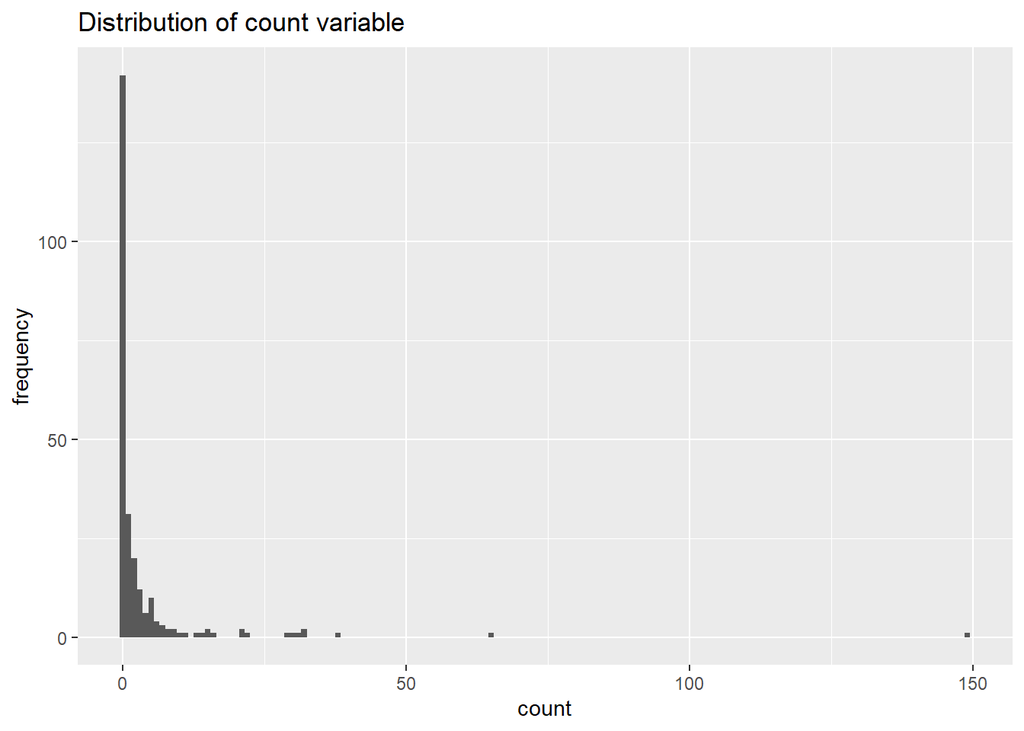

```r
ggplot(df_fish, aes(x = count)) +
  geom_histogram(binwidth = 1) +
  labs(x = 'count', y = 'frequency', title = 'Distribution of count variable')
```

Предположим, что переменная имеет распределение Пуассона. Будем использовать пуассоновскую регрессию.
$$P(y=k)=exp(-\lambda) \lambda^k / k!$$
где $\lambda=\exp(b_1 +b_2*x)$

```r
poisson_model = glm(count ~ child + camper +  persons, family = "poisson", data = df_fish)
summary(poisson_model)
```

```
Call:
glm(formula = count ~ child + camper + persons, family = "poisson",
    data = df_fish)

Deviance Residuals:
    Min       1Q   Median       3Q      Max
-6.8096  -1.4431  -0.9060  -0.0406  16.1417

Coefficients:
            Estimate Std. Error z value Pr(>|z|)
(Intercept) -1.98183    0.15226  -13.02   <2e-16 ***
child       -1.68996    0.08099  -20.87   <2e-16 ***
camper1      0.93094    0.08909   10.45   <2e-16 ***
persons      1.09126    0.03926   27.80   <2e-16 ***
---
Signif. codes:  0 '***' 0.001 '**' 0.01 '*' 0.05 '.' 0.1 ' ' 1

(Dispersion parameter for poisson family taken to be 1)

    Null deviance: 2958.4  on 249  degrees of freedom
Residual deviance: 1337.1  on 246  degrees of freedom
AIC: 1682.1

Number of Fisher Scoring iterations: 6
```

Посчитаем средний предельный эффект для каждой переменной.

```r
m = margins(poisson_model)
summary(m)
```

```
  factor     AME     SE        z      p   lower   upper
 camper1  2.5815 0.2137  12.0800 0.0000  2.1626  3.0003
   child -5.5701 0.3300 -16.8779 0.0000 -6.2169 -4.9233
 persons  3.5968 0.1801  19.9697 0.0000  3.2438  3.9498
```

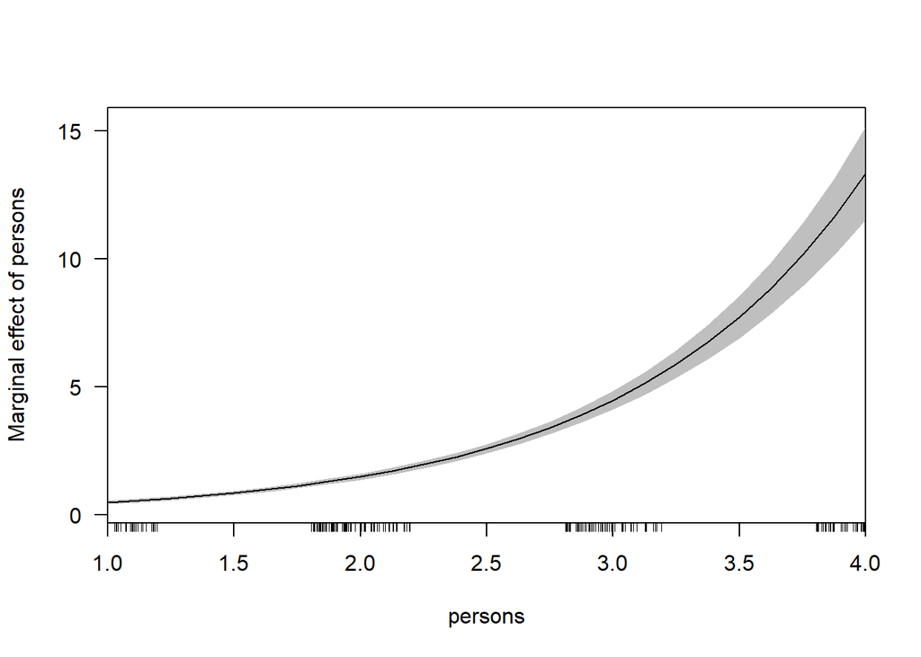

```r
cplot(poisson_model, x = 'persons', what = 'effect', title = 'Предельный эффект переменной camper')
```

```r
margins(poisson_model, at = list(child = 0:1))
```

```
 at(child)   child persons camper1
         0 -12.948   8.361   6.343
         1  -2.389   1.543   1.171
```

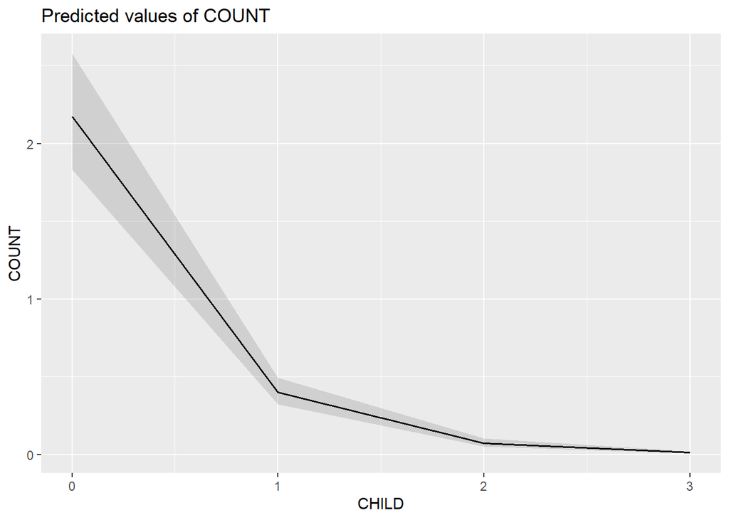

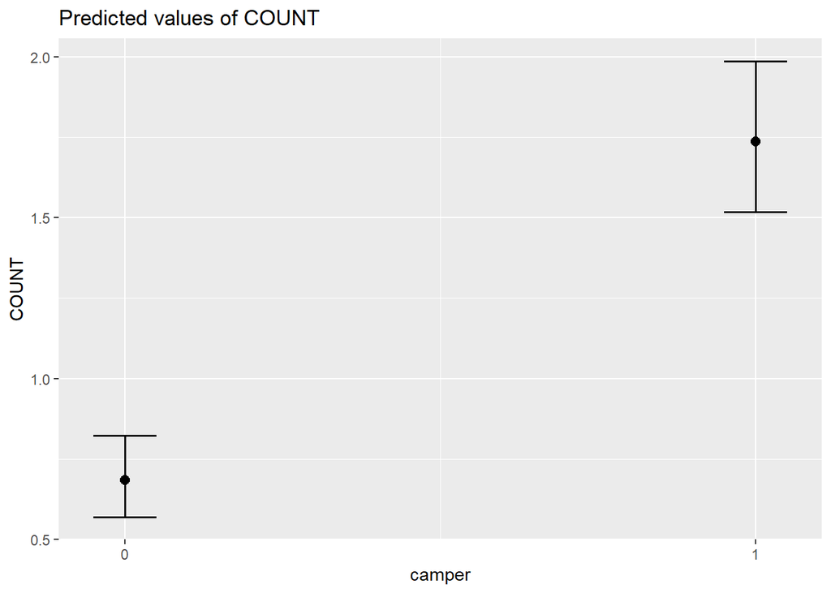

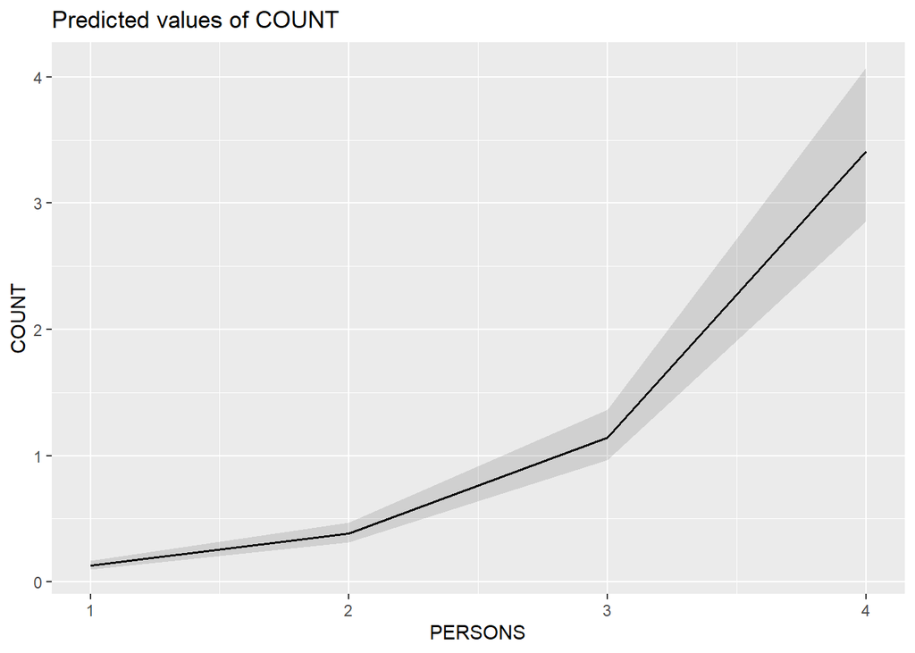

```r
plot_model(poisson_model, type = 'pred')
```

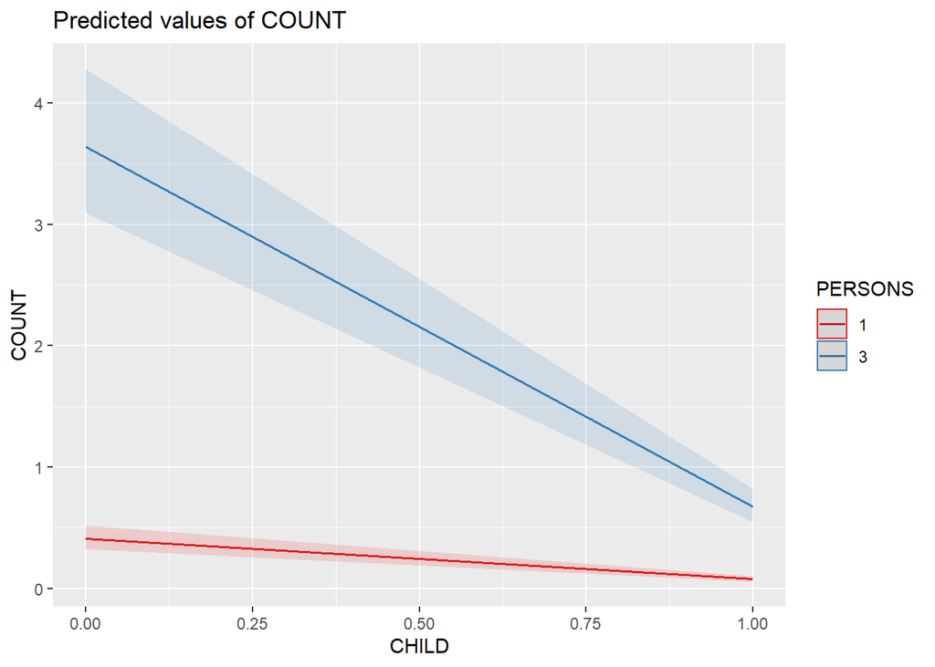

```r
plot_model(poisson_model, type = "pred", terms = c("child [0, 0, 1]", "persons [1,3]"))
```

Однако, заметим, что дисперсия и среднее значение объясняемой переменной не равны, как это предполагает распределение Пуассона.

```r
df_fish %>%
  group_by(camper) %>%
  summarize(var = var(count), mean = mean(count))
```

```
# A tibble: 2 x 3
  camper   var  mean
  <fct>  <dbl> <dbl>
1 0       21.1  1.52
2 1      212.   4.54
```

Оценим регрессию, предполагая отрицательное биномиальное распределение остатков. В этом случае, дисперсия распределения зависит от некоторого параметра и не равна среднему.

```r
nb1 = glm.nb(count ~ child + camper +  persons, data = df_fish)
summary(nb1)
```

```
Call:
glm.nb(formula = count ~ child + camper + persons, data = df_fish,
    init.theta = 0.4635287626, link = log)

Deviance Residuals:
    Min       1Q   Median       3Q      Max
-1.6673  -0.9599  -0.6590  -0.0319   4.9433

Coefficients:
            Estimate Std. Error z value Pr(>|z|)
(Intercept)  -1.6250     0.3304  -4.918 8.74e-07 ***
child        -1.7805     0.1850  -9.623  < 2e-16 ***
camper1       0.6211     0.2348   2.645  0.00816 **
persons       1.0608     0.1144   9.273  < 2e-16 ***
---
Signif. codes:  0 '***' 0.001 '**' 0.01 '*' 0.05 '.' 0.1 ' ' 1

(Dispersion parameter for Negative Binomial(0.4635) family taken to be 1)

    Null deviance: 394.25  on 249  degrees of freedom
Residual deviance: 210.65  on 246  degrees of freedom
AIC: 820.44

Number of Fisher Scoring iterations: 1

              Theta:  0.4635
          Std. Err.:  0.0712

 2 x log-likelihood:  -810.4440
```

Попробуем исключить из модели переменную `camper` и сравним качество двух моделей.

```r
nb2 = update(nb1, . ~ . - camper)
waldtest(nb1, nb2)
```

```
Wald test

Model 1: count ~ child + camper + persons
Model 2: count ~ child + persons
  Res.Df Df      F   Pr(>F)
1    246
2    247 -1 6.9979 0.008686 **
---
Signif. codes:  0 '***' 0.001 '**' 0.01 '*' 0.05 '.' 0.1 ' ' 1
```

Можем посмотреть на результаты модели с “раздутыми нулями” (zero-inflated). Они предполагают большую частоту нулевых наблюдений.

```r
zero_infl = zeroinfl(count ~  child + camper | persons, data = df_fish, dist = 'negbin')
summary(zero_infl)
```

```
Call:
zeroinfl(formula = count ~ child + camper | persons, data = df_fish,
    dist = "negbin")

Pearson residuals:
    Min      1Q  Median      3Q     Max
-0.5861 -0.4617 -0.3886 -0.1974 18.0135

Count model coefficients (negbin with log link):
            Estimate Std. Error z value Pr(>|z|)
(Intercept)   1.3710     0.2561   5.353 8.64e-08 ***
child        -1.5153     0.1956  -7.747 9.41e-15 ***
camper1       0.8791     0.2693   3.265   0.0011 **
Log(theta)   -0.9854     0.1760  -5.600 2.14e-08 ***

Zero-inflation model coefficients (binomial with logit link):
            Estimate Std. Error z value Pr(>|z|)
(Intercept)   1.6031     0.8365   1.916   0.0553 .
persons      -1.6666     0.6793  -2.453   0.0142 *
---
Signif. codes:  0 '***' 0.001 '**' 0.01 '*' 0.05 '.' 0.1 ' ' 1

Theta = 0.3733
Number of iterations in BFGS optimization: 22
Log-likelihood: -432.9 on 6 Df
```

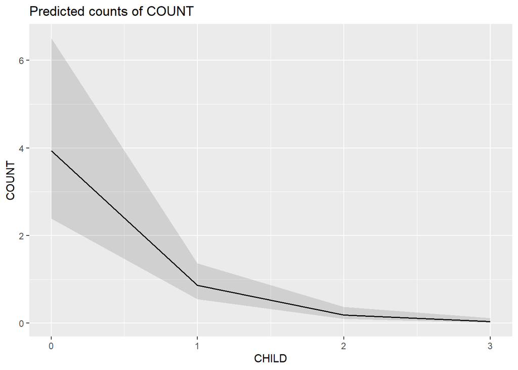

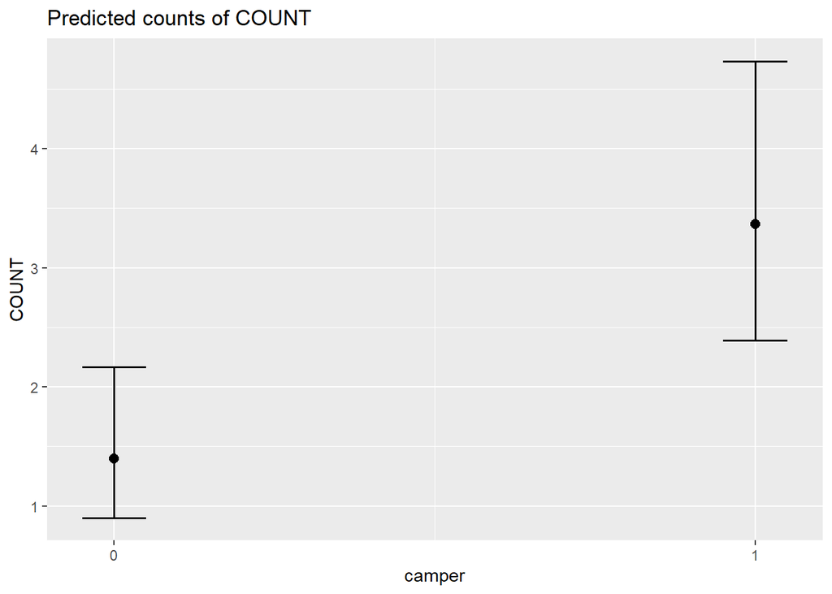

```r
plot_model(zero_infl, type = 'pred')
```

## python

Загрузим ужные пакетики.

```python
import pandas as pd # работа с таблицами
import numpy as np # математика, работа с матрицами
import matplotlib.pyplot as plt # графики
import statsmodels.api as sm
import statsmodels.formula.api as smf
import statsmodels.graphics.gofplots as gf
from statsmodels.stats.outliers_influence import summary_table
import seaborn as sns # еще более классные графики
from scipy.stats import shapiro # еще математика
import statsmodels.discrete.discrete_model
from statsmodels.discrete.count_model import ZeroInflatedPoisson

plt.style.use('ggplot')
```

```python
df_fish = pd.read_stata('data/fish.dta')
```

Посмотрим, как выглядит распределение объясняемой переменной.

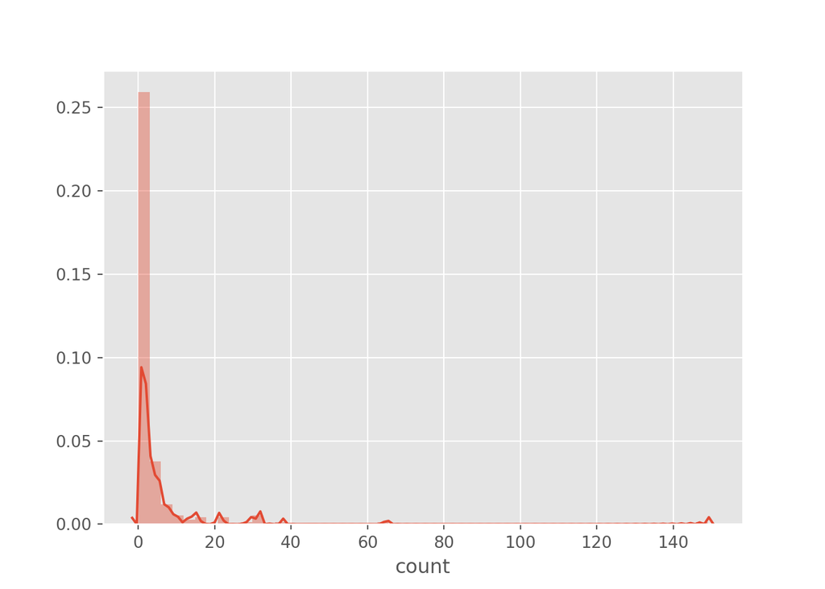

```python
sns.distplot(df_fish['count'])
plt.show()
```

Превращаем переменную `camper` в категориальную.

```python
df_fish['camper'] = df_fish['camper'].astype('category')
```

Строим Пуассоновскую регрессию.

```python
regr_pois = smf.glm('count ~ child + camper +  persons', data=df_fish,
                    family=sm.families.Poisson()).fit()
regr_pois.summary()
```

```
<class 'statsmodels.iolib.summary.Summary'>
"""
                 Generalized Linear Model Regression Results
==============================================================================
Dep. Variable:                  count   No. Observations:                  250
Model:                            GLM   Df Residuals:                      246
Model Family:                 Poisson   Df Model:                            3
Link Function:                    log   Scale:                          1.0000
Method:                          IRLS   Log-Likelihood:                -837.07
Date:                Thu, 16 Jan 2020   Deviance:                       1337.1
Time:                        17:06:30   Pearson chi2:                 2.91e+03
No. Iterations:                     6
Covariance Type:            nonrobust
===============================================================================
                  coef    std err          z      P>|z|      [0.025      0.975]
-------------------------------------------------------------------------------
Intercept      -1.9818      0.152    -13.016      0.000      -2.280      -1.683
camper[T.1]     0.9309      0.089     10.450      0.000       0.756       1.106
child          -1.6900      0.081    -20.866      0.000      -1.849      -1.531
persons         1.0913      0.039     27.799      0.000       1.014       1.168
===============================================================================
"""
```

Посмотрим, равны ли среднее значение и дисперсия, как это предполагает распределение Пуассона.

```python
(df_fish
 .filter(['count', 'camper'])
 .groupby('camper')
 .agg(['mean', 'var']))
```

```
           count
            mean         var
camper
0       1.524272   21.055778
1       4.537415  212.400988
```

И регрессию с остатками, имеющими отрицательное биномиальное распределение.

```python
regr_bin = smf.glm('count ~ child + camper +  persons', data=df_fish,
              family=sm.families.NegativeBinomial()).fit()

regr_bin.summary()
```

```
<class 'statsmodels.iolib.summary.Summary'>
"""
                 Generalized Linear Model Regression Results
==============================================================================
Dep. Variable:                  count   No. Observations:                  250
Model:                            GLM   Df Residuals:                      246
Model Family:        NegativeBinomial   Df Model:                            3
Link Function:                    log   Scale:                          1.0000
Method:                          IRLS   Log-Likelihood:                -417.63
Date:                Thu, 16 Jan 2020   Deviance:                       316.92
Time:                        17:06:30   Pearson chi2:                     938.
No. Iterations:                     8
Covariance Type:            nonrobust
===============================================================================
                  coef    std err          z      P>|z|      [0.025      0.975]
-------------------------------------------------------------------------------
Intercept      -1.6582      0.261     -6.351      0.000      -2.170      -1.147
camper[T.1]     0.6599      0.182      3.636      0.000       0.304       1.016
child          -1.7314      0.147    -11.787      0.000      -2.019      -1.443
persons         1.0547      0.086     12.253      0.000       0.886       1.223
===============================================================================
"""
```

```python
hyp = '(child = 0)'
regr_bin.wald_test(hyp)
```

```
<class 'statsmodels.stats.contrast.ContrastResults'>
<Wald test (chi2): statistic=[[138.9233986]], p-value=4.577705644902091e-32, df_denom=1>
```

```python
pred = regr_pois.fittedvalues
mean_mef_child = np.mean([regr_pois.params[1]*p for p in pred])
mean_mef_camper = np.mean([regr_pois.params[2]*p for p in pred])

data_1 = pd.DataFrame({'child': df_fish['child'], 'camper': 1, 'persons': df_fish['persons']})
data_0 = pd.DataFrame({'child': df_fish['child'], 'camper': 0, 'persons': df_fish['persons']})
mean_mef_persons = np.mean([(regr_pois.predict(data_1)[i]-regr_pois.predict(data_0)[i])
                            for i in range(len(df_fish))])
```

```python
plot_model(regr_pois, type='effect', terms='camper')
```

[output not shown]

И модель с раздутыми нулями. (которая у меня не получилась :( )